# Selective Inference Example

Suppose that:
$$\left[ \begin{array}{c} Y_\beta \\ Y_{\delta}
\end{array}
\right] \sim \mbox{N}\left( \left[
\begin{array}{c}
\beta \\ \delta
\end{array}
\right], \left[
\begin{array}{cc}
1 & \rho \\
\rho & 1\\
\end{array}
\right]\right), \quad A = \{|Y_\delta| > c\}$$
The quantity $U = Y_\delta - \rho Y_\beta$ is a sufficient statistic for $\delta$ and we have
$$\left.\left[
\begin{array}{c}
Y_\beta \\ Y_{\delta}
\end{array}
\right] \right| (U=u)
= \left[
\begin{array}{c}
\beta + Z \\ u + \rho (\beta + Z)
\end{array}
\right], \quad Z \sim \mbox{N}(0,1)$$

In class we calculated the conditional distribution of $Y_\beta$ under $H_0\colon \beta = \beta_0$ given $U=u$ and $A$ or $A^c$. The following R code implements the corresponding CDF:

```r
conditionalCDF <- function(y, b, u, rho, crit, A) {
  L <- (-crit - u) / rho
  R <- (crit - u) / rho
  Phi_y <- pnorm(y - b)
  Phi_R <- pnorm(R - b)
  Phi_L <- pnorm(L - b)

  if(A) {
    denom <- 1 - Phi_R + Phi_L
    num1 <- (y < L) * Phi_y
    num2 <- ((y >= L) & (y <= R)) * Phi_L
    num3 <- (y > R) * (Phi_y - Phi_R + Phi_L)
  } else {
    denom <- Phi_R - Phi_L
    num1 <- (y < L) * 0
    num2 <- ((y >= L) & (y <= R)) * (Phi_y - Phi_L)
    num3 <- (y > R) * (Phi_R - Phi_L)
  }
  return((num1 + num2 + num3) / denom)
}
```

We can easily invert the proceeding to get a quantile function:

```r
conditionalQuantile <- function(p, b, u, rho, crit, A) {
  L <- (-crit - u) / rho
  R <- (crit - u) / rho
  Phi_R <- pnorm(R - b)
  Phi_L <- pnorm(L - b)

  if(A) {
    denom <- 1 - Phi_R + Phi_L
    pstar <- Phi_L / denom
    argument <- p * denom + (p > pstar) * (Phi_R - Phi_L)
  } else {
    denom <- Phi_R - Phi_L
    argument <- p * denom + Phi_L
  }
  return(b + qnorm(argument))
}
```

Here’s a function to plot the CDF:

```r
plotCDF <- function(b, u, rho, crit, A) {
  eps <- 0.0001
  ylower <- conditionalQuantile(p = eps, b, u, rho, crit, A)
  yupper <- conditionalQuantile(p = 1 - eps, b, u, rho, crit, A)
  yseq <- seq(ylower, yupper, length.out = 501)
  Fseq <- conditionalCDF(yseq, b, u, rho, crit, A)
  plot(yseq, Fseq, type = 'l', xlab = 'y', ylab = 'CDF')
  abline(v = (-crit - u) / rho, lty = 2, col = 'red')
  abline(v = (crit - u) / rho, lty = 2, col = 'red')
}
```

and here’s one to plot the quantile function:

```r
plotQuantile <- function(b, u, rho, crit, A) {
  eps <- 0.0001
  pseq <- seq(eps, 1 - eps, length.out = 501)
  Qseq <- conditionalQuantile(pseq, b, u, rho, crit, A)
  plot(pseq, Qseq, type = 'l', xlab = 'p', ylab = 'Quantile')
  abline(h = (-crit - u) / rho, lty = 2, col = 'red')
  abline(h = (crit - u) / rho, lty = 2, col = 'red')
}
```

Now let’s make some plots under the null $\beta = 0$. First we’ll condition on $A$ and use a critical value of $2$ for the first-stage test

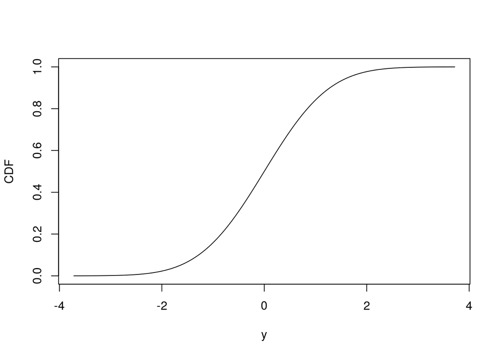

```r
plotCDF(b = 0, u = -10, rho = 0.5, crit = 2, A = TRUE)
```

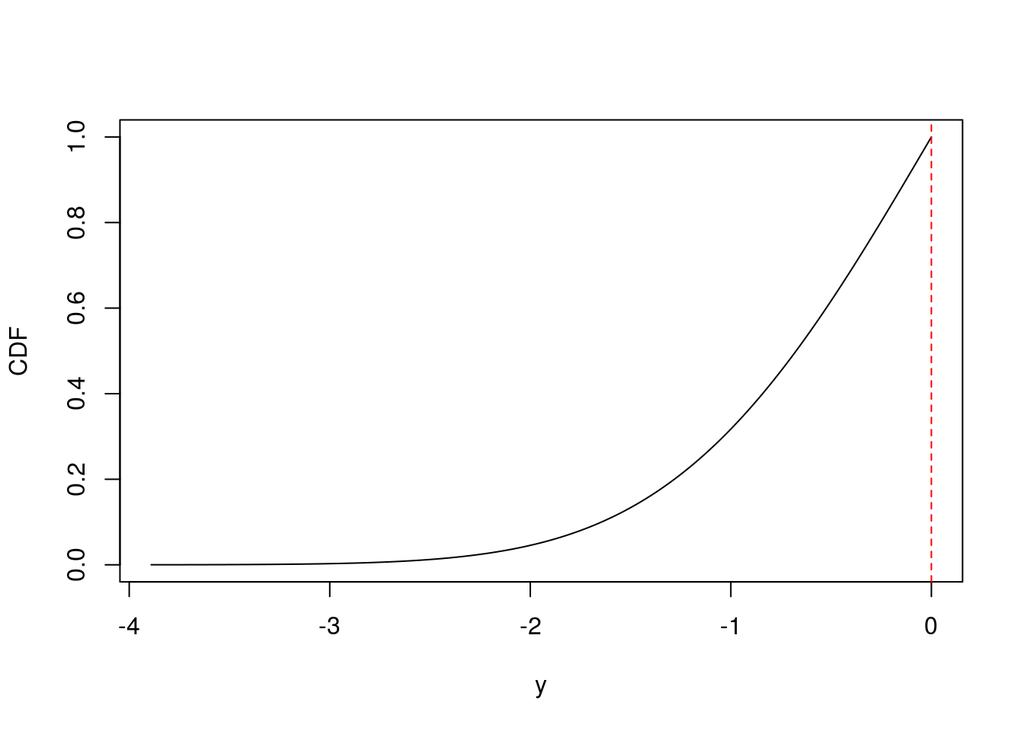

```r
plotCDF(b = 0, u = -2, rho = 0.5, crit = 2, A = TRUE)
```

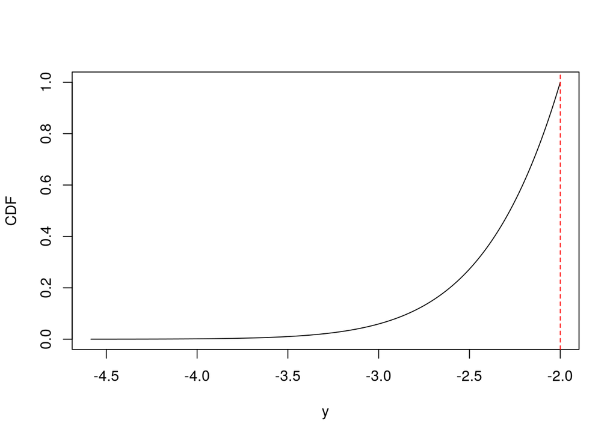

```r
plotCDF(b = 0, u = -1, rho = 0.5, crit = 2, A = TRUE)
```

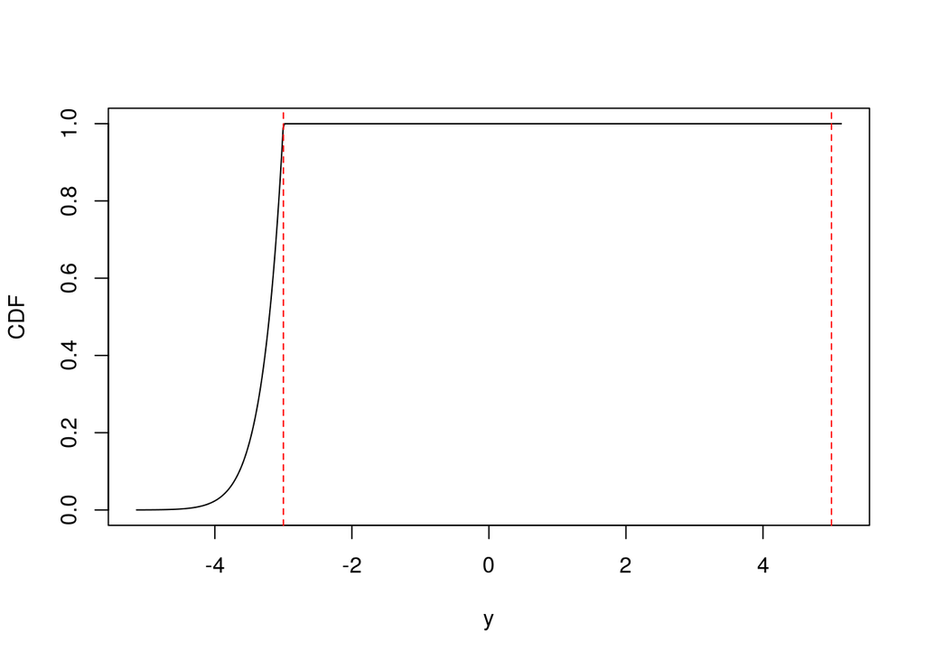

```r
plotCDF(b = 0, u = -0.5, rho = 0.5, crit = 2, A = TRUE)
```

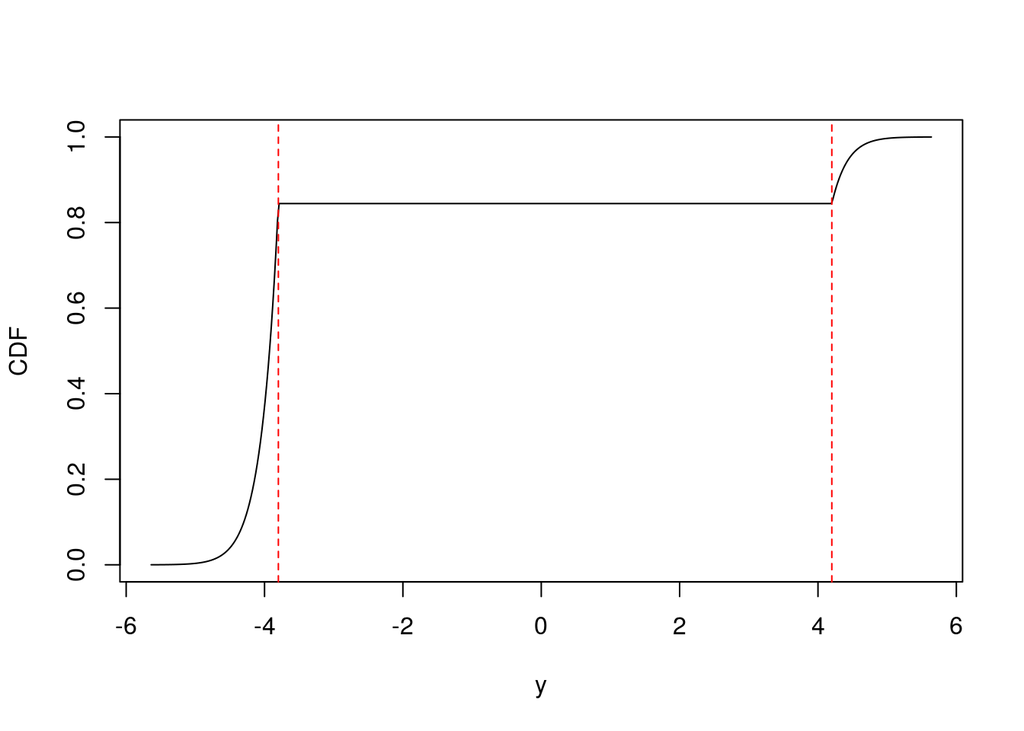

```r
plotCDF(b = 0, u = -0.1, rho = 0.5, crit = 2, A = TRUE)
```

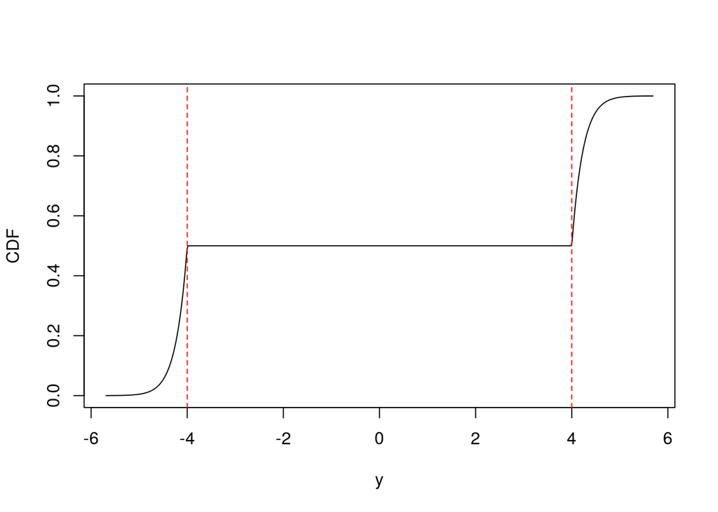

```r
plotCDF(b = 0, u = 0, rho = 0.5, crit = 2, A = TRUE)
```

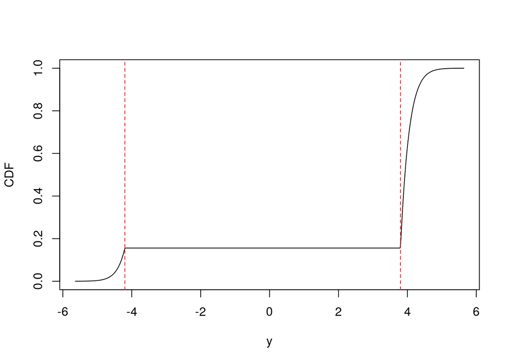

```r
plotCDF(b = 0, u = 0.1, rho = 0.5, crit = 2, A = TRUE)
```

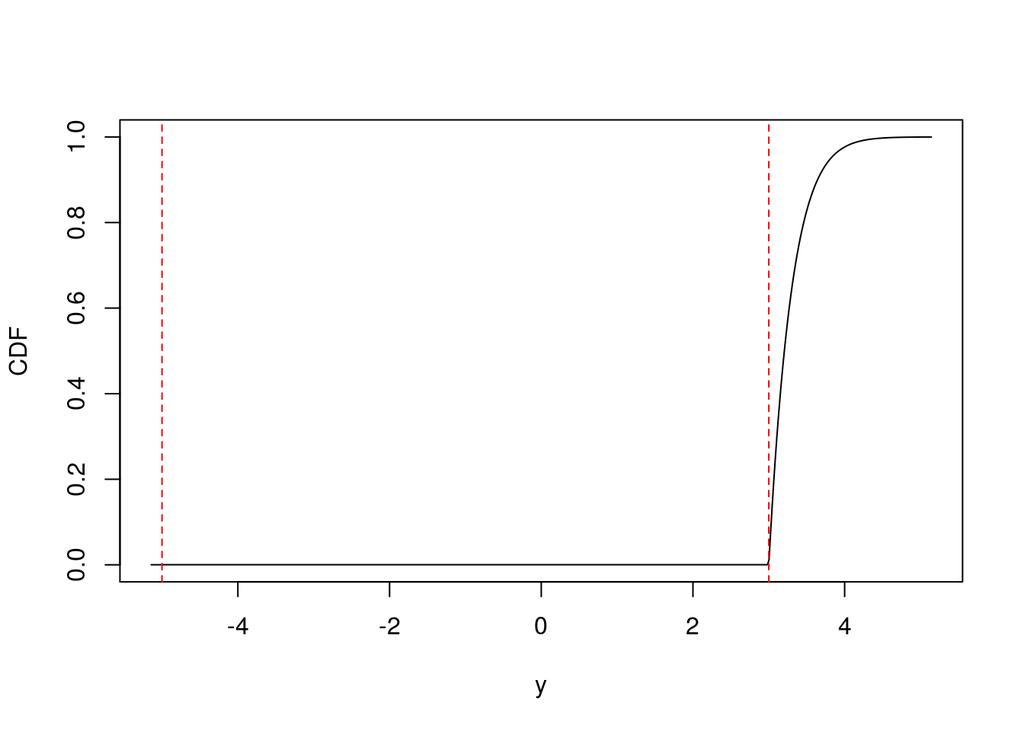

```r
plotCDF(b = 0, u = 0.5, rho = 0.5, crit = 2, A = TRUE)
```

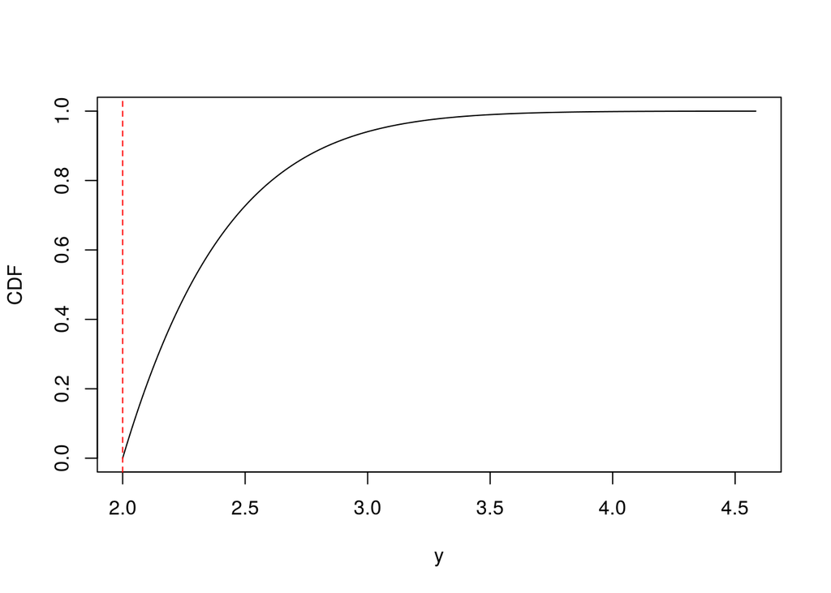

```r
plotCDF(b = 0, u = 1, rho = 0.5, crit = 2, A = TRUE)
```

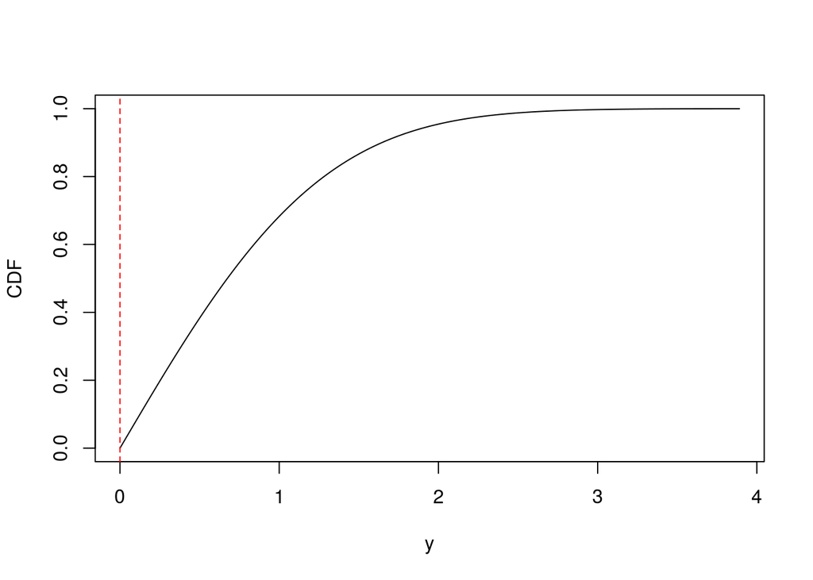

```r
plotCDF(b = 0, u = 2, rho = 0.5, crit = 2, A = TRUE)
```

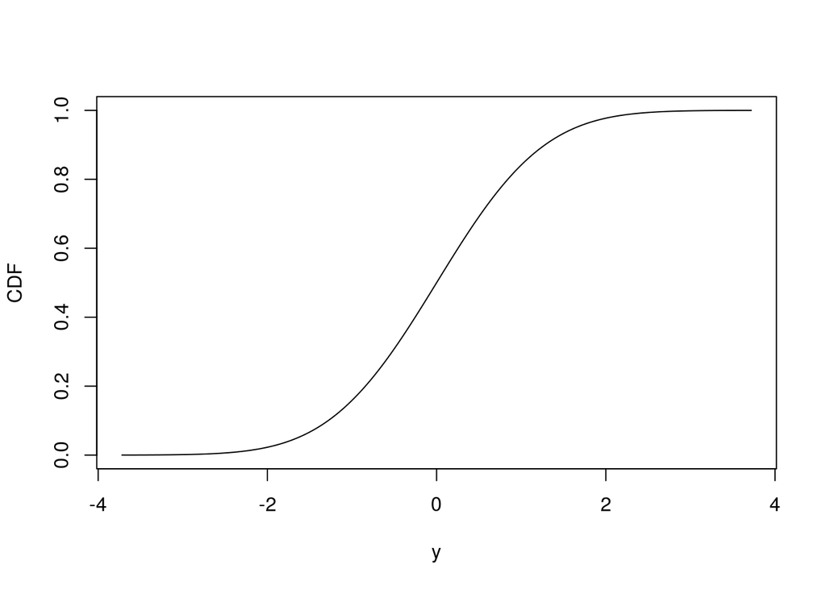

```r
plotCDF(b = 0, u = 10, rho = 0.5, crit = 2, A = TRUE)
```

Now the same thing, but conditioning on $A^c$:

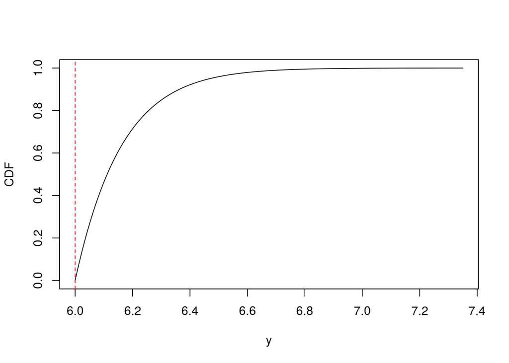

```r
plotCDF(b = 0, u = -5, rho = 0.5, crit = 2, A = FALSE)
```

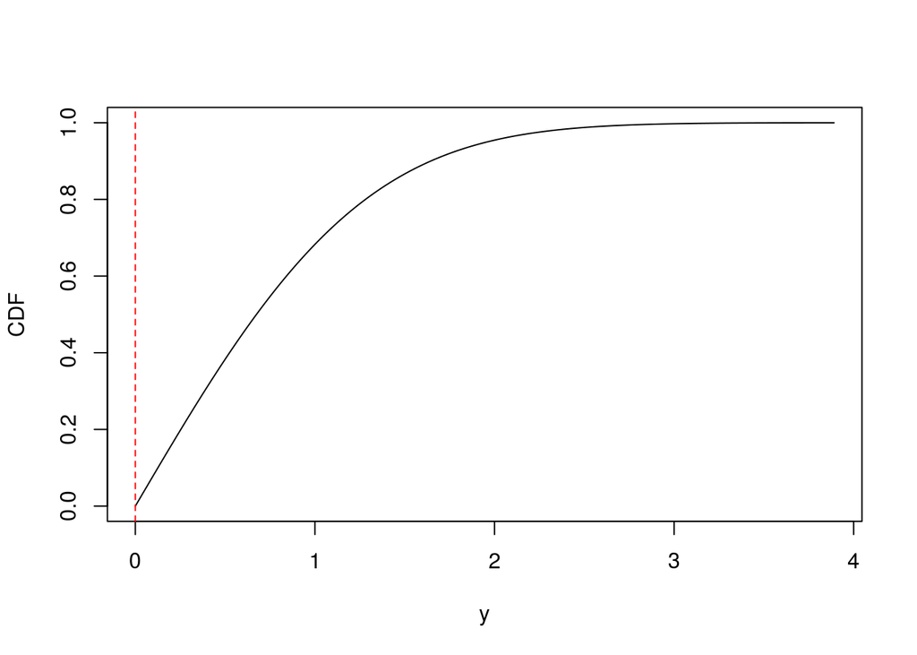

```r
plotCDF(b = 0, u = -2, rho = 0.5, crit = 2, A = FALSE)
```

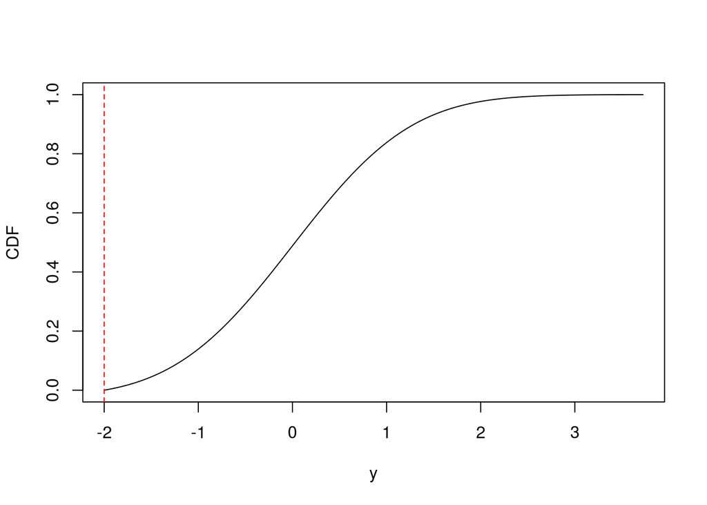

```r
plotCDF(b = 0, u = -1, rho = 0.5, crit = 2, A = FALSE)
```

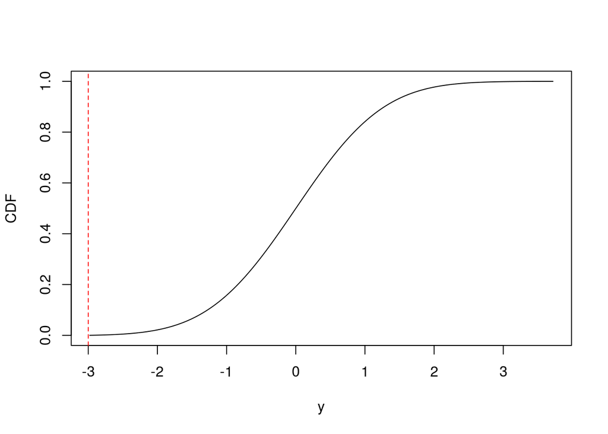

```r
plotCDF(b = 0, u = -0.5, rho = 0.5, crit = 2, A = FALSE)
```

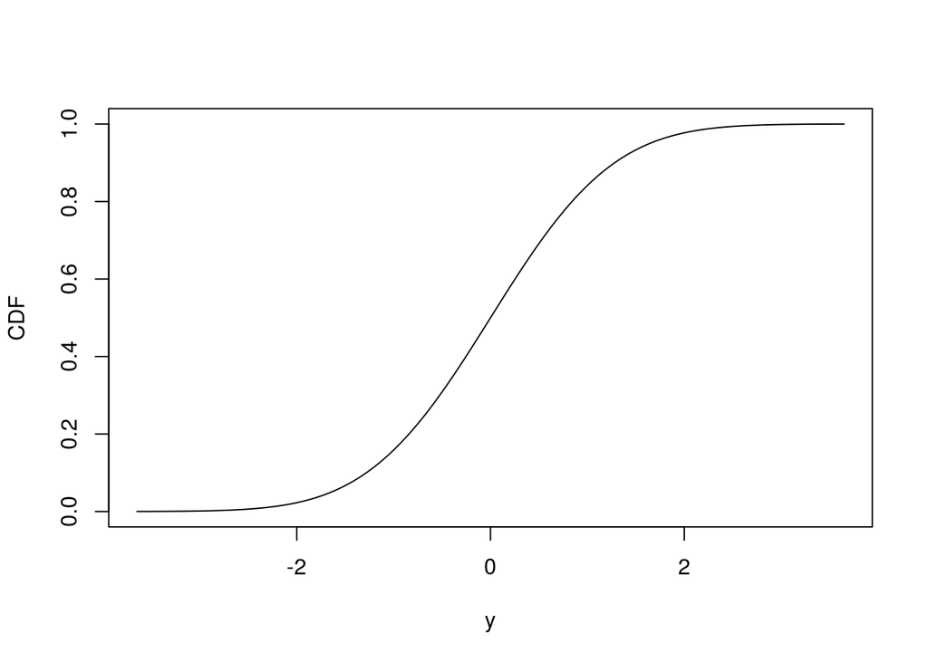

```r
plotCDF(b = 0, u = 0, rho = 0.5, crit = 2, A = FALSE)
```

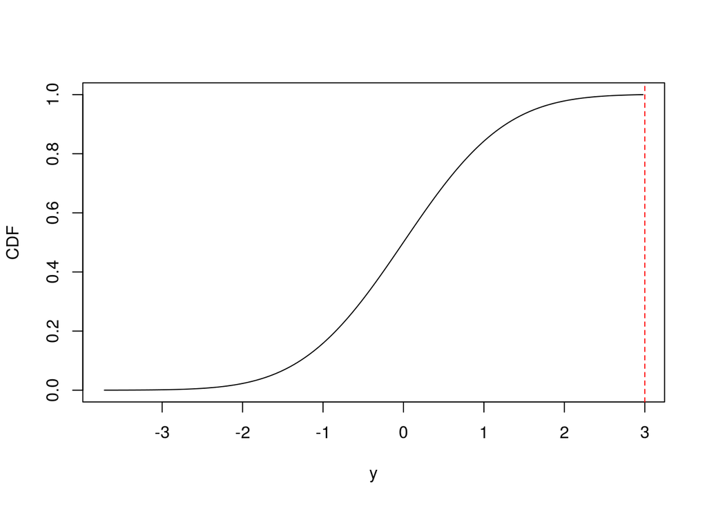

```r
plotCDF(b = 0, u = 0.5, rho = 0.5, crit = 2, A = FALSE)
```

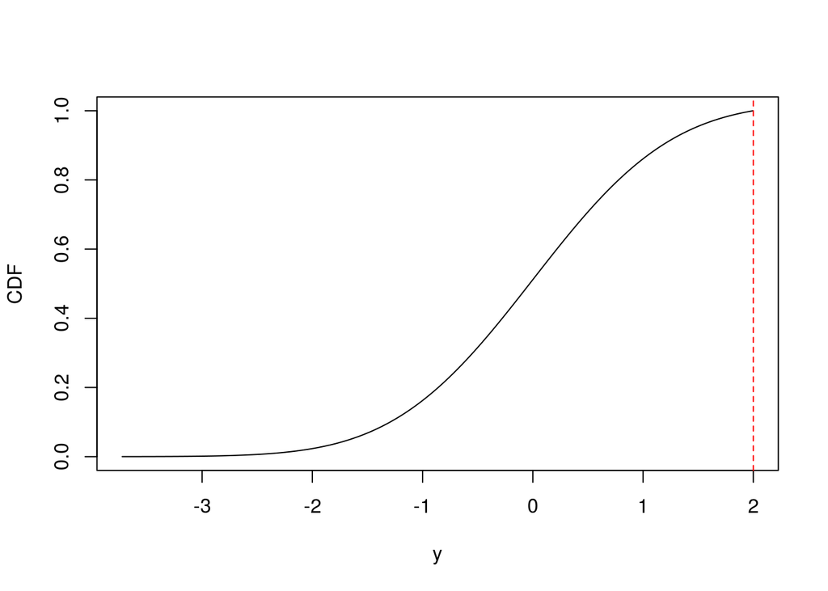

```r
plotCDF(b = 0, u = 1, rho = 0.5, crit = 2, A = FALSE)
```

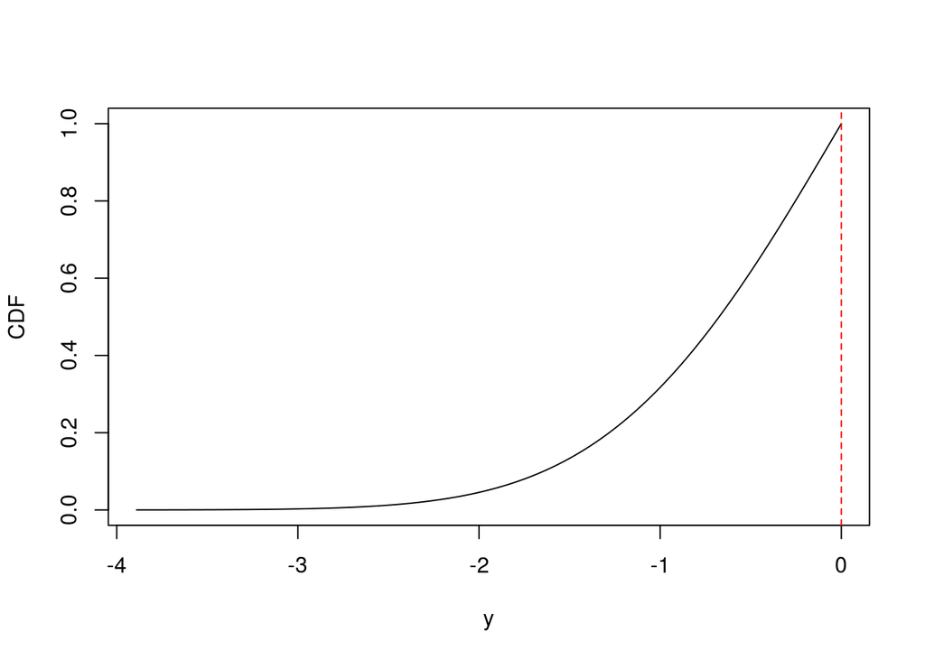

```r
plotCDF(b = 0, u = 2, rho = 0.5, crit = 2, A = FALSE)
```

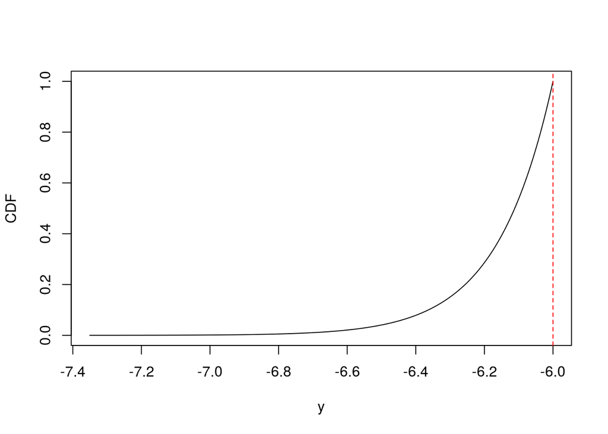

```r
plotCDF(b = 0, u = 5, rho = 0.5, crit = 2, A = FALSE)
```

Now let’s try a simple simulation experiment. First we’ll set values of $\beta$, $\delta$, $\rho$, $c$ and the number of simulation draws:

```r
b <- 0
d <- 1
r <- 0.4
crit <- qnorm(1 - 0.05 / 2)
n <- 1000000
```

Now we make $n$ bivariate standard normal draws with correlation $\rho$

```r
set.seed(1234)
y <- MASS::mvrnorm(n, c(b, d), Sigma = matrix(c(1, r, r, 1), 2, 2, byrow = TRUE))
Yb <- y[,1]
Yd <- y[,2]
```

The preceding are draws from the *unconditional* joint distribution of $Y_\beta$ and and $Y_\delta$. Now we’ll condition on the event $A$, by keeping only the subset of draws for which $Y_\delta$ is larger in absolute value that $c$.

```r
yA <- y[abs(Yd) > crit,]
yA <- yA[sample(1:nrow(yA), 10000),]
Yb_A <- yA[,1]
Yd_A <- yA[,2]
```

Notice the difference between the conditional and unconditional distributions of $Y_\beta$:

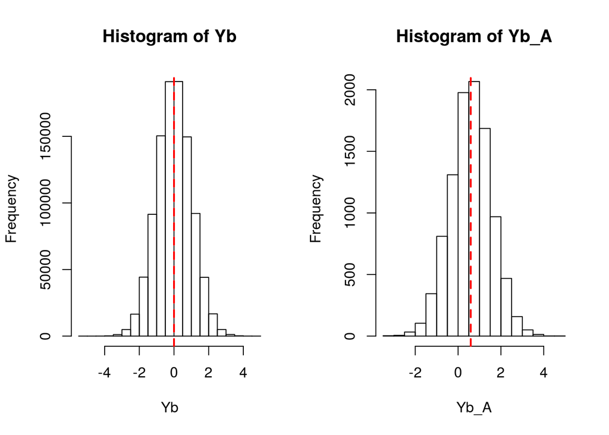

```r
par(mfrow = c(1, 2))
hist(Yb)
abline(v = mean(Yb), col = 'red', lty = 2, lwd = 2)
hist(Yb_A)
abline(v = mean(Yb_A), col = 'red', lty = 2, lwd = 2)
```

```r
par(mfrow = c(1, 1))
```

Suppose that we want to test against the one-sided alternative, namely $H_0\colon \beta = 0$ versus $H_1\colon \beta > 0$ with $\alpha = 0.05$. Now we’ll plot the critical value for a valid selective test. This is a function of the observed value of $U$. Let’s see how it compares to the critical value we’d get if we hadn’t conditioned on $A$:

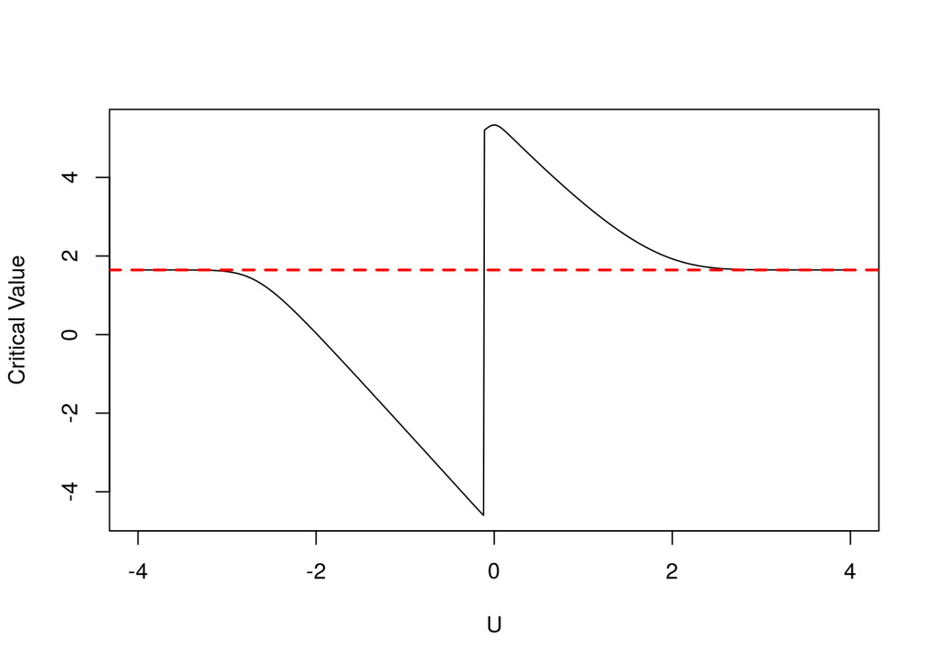

```r
Useq <- seq(-4, 4, 0.01)
critical_values <- conditionalQuantile(0.95, b, Useq, rho = r, crit, A = TRUE)
plot(Useq, critical_values, type = 'l', xlab = 'U', ylab = 'Critical Value')
abline(h = qnorm(0.95), col = 'red', lty = 2, lwd = 2)
```

Now let’s check that this works in our simulation study. First we’ll construct the observed sufficient statistics, and then we’ll calculate the selective critical value for each one:

```r
U <- Yd_A - r * Yb_A
critical_values <- conditionalQuantile(0.95, b, U, rho = r, crit, A = TRUE)
```

Now we’ll carry out the test: rejecting if $Y_\beta$ exceeds the conditional conditional critical value, given $U=u$. Since the null is true, we should reject with probability $\alpha = 0.05$

```r
mean(Yb_A > critical_values)
```

```
## [1] 0.0508
```

Now compare this to what we would have gotten if we had ignored the effects of our first-step selection procedure on subsequent inference:

```r
mean(Yb_A > qnorm(0.95))
```

```
## [1] 0.1295
```